# All my homework

## Answer

```r
# example 8.1
data("chickwts")
x <- sort(as.vector(chickwts[chickwts$feed == "soybean",1]))
m<-length(x)
y <- sort(as.vector(chickwts[chickwts$feed == "linseed",1]))
n<-length(y)
```

```r
set.seed(123)
cvm_statistic <- function(x, y) {
  Fn <- ecdf(x)  # ECDF for sample x
  Gm <- ecdf(y)  # ECDF for sample y
  # Cramer-von Mises statistic
  s <- (n * m) / (n + m)^2 * (
    sum((Fn(x) - Gm(x))^2) +
    sum((Fn(y) - Gm(y))^2)
  )
  return(s)
}
cvm0<-cvm_statistic(x,y)
M<-1000
cvm<-numeric(M)
for (i in 1:M) {
  z<-sample(c(x,y))
  cvm[i]<-cvm_statistic(z[1:m],z[(m+1):(m+n)])
}
print(paste0("p值为：",round((sum(cvm>=cvm0)+1)/(M+1),3)))
```

```
## [1] "p值为：0.423"
```

“p值为：0.423”,故认为原假设成立，认为X、Y分布相同

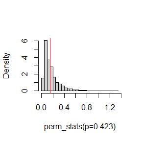

```r
#直方图
hist(cvm, main = "", xlab = "perm_stats(p=0.423)",freq = FALSE, breaks = "scott")
abline(v=cvm0,col="red") #observed W2
```

## Question

Implement the bivariate Spearman rank correlation test for independence [255] as a permutation test.

## Answer

```r
#生成数据
library(MASS)
# 定义均值向量
mean_vector <- c(0, 0)  # 假设有两个变量，均值为0
# 定义协方差矩阵
cov_matrix <- matrix(c(1, 0.5, 0.5, 1), nrow = 2)  # 假设两个变量之间的相关性为0.5
# 生成20个样本
samples <- mvrnorm(20, mu = mean_vector, Sigma = cov_matrix)
```

```r
x<-samples[,1]
y<-samples[,2]
# the observed Spearman correlation
cor0 <- cor(x, y, method = "spearman")
#  the permutation
perm_test_spearman <- function(x, y, M = 1000) {
  permuted_corrs <- numeric(M)
  combined <- c(x, y)
  n = length(x)
  m = length(y)
  for (i in 1:M) {
    permuted_index <- sample(1:(n+m), n, FALSE)
    permuted_corrs[i] <- cor(combined[permuted_index], combined[-permuted_index], method = "spearman")
  }
  return(permuted_corrs)
}

M <- 1000
permuted_corrs <- perm_test_spearman(x, y, M)

#  p-value
p_value_perm <- mean(abs(permuted_corrs) >= abs(cor0))

# p-value from cor.test
spearman_test <- cor.test(x, y, method = "spearman")

# Results
cat("Observed Spearman correlation:", round(cor0,3), "\n")
```

```
## Observed Spearman correlation: 0.644
```

```r
cat("Permutation p-value:", round(p_value_perm,4), "\n")
```

```
## Permutation p-value: 0.001
```

```r
cat("Spearman test p-value:", round(spearman_test$p.value,4), "\n")
```

```
## Spearman test p-value: 0.0028
```

# hw6

## Question

Use the Metropolis-Hastings sampler to generate random variables from a standard Cauchy distribution. Discard the first 1000 of the chain, and compare the deciles of the generated observations with the deciles of the standard Cauchy distribution (see qcauchy or qt with df=1).

## Answer

```r
rm(list=ls())
```

```r
set.seed(123)
# M-H生成Cauchy
MH<-function(n,cut=1000){
  x<-numeric(n)
  x[1]<-rnorm(1,0,1)
  U<-runif(n)
  for (i in 2:n) {
    a<-rnorm(1,x[i-1],1)
    ifelse(U[i]<=((1+x[i-1]^2)/(1+a^2)),x[i]<-a,x[i]<-x[i-1])
  }
  x<-x[(cut+1):n]
  return(x)
}
sim_cauchy<-MH(5000)
#比较分位数
quantile(sim_cauchy, probs = seq(0.1, 0.9, by = 0.1)) #deciles of MH
```

```
##         10%         20%         30%         40%         50%         60%
## -2.24832078 -1.20733834 -0.66905669 -0.31160712 -0.03116382  0.28300264
##         70%         80%         90%
##  0.66948716  1.26009803  2.88695235
```

```r
qt(seq(0.1, 0.9, by = 0.1),1) #deciles of the standard Cauchy distribution
```

```
## [1] -3.0776835 -1.3763819 -0.7265425 -0.3249197  0.0000000  0.3249197  0.7265425
## [8]  1.3763819  3.0776835
```

通过分位数的比较可见，M-H算法得到的Cauchy分布跟真实类似，但比实际更集中，看起来方差偏小。

## Question

Consider the bivariate density.It can be shown (see e.g. [23]) that for fixed a, b, n, the conditional distributions are Binomial(n, y) and Beta(x + a, n − x + b). Use the Gibbs sampler to generate a chain with target joint density f(x, y).

## Answer

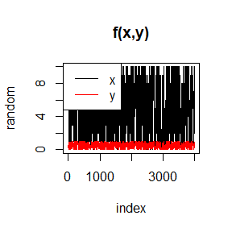

```r
set.seed(123)
gibb<-function(m,cut,n=10,a=1,b=1){
  x<-numeric(m)
  y<-numeric(m)
  x[1]<-rbinom(1,n,1/2)
  y[1]<-rbeta(1,x[1]+a,n-x[1]+b)
  for (i in 2:m) {
    x[i]<-rbinom(1,n,y[i-1])
    y[i]<-rbeta(1,x[i-1]+a,n-x[i-1]+b)
  }
  x<-x[(cut+1):m]
  y<-y[(cut+1):m]
  f<-matrix(c(x,y),nrow = (m-cut),ncol = 2)
}
#. Use the Gibbs sampler to generate a chain with target joint density f(x, y)
# n=10,a=1,b=1
gib<-gibb(5000,1000)

# 绘制马氏链折线图
plot(gib[,1], type = "l", main = "f(x,y)", xlab = "index", ylab = "random")
lines(gib[,2],col="red")
legend("topleft", legend = c("x", "y"), col = c("black", "red"), lty = 1)
```

## Question

For each of the above exercise, use the Gelman-Rubin method to monitor convergence of the chain, and run the chain until it converges approximately to the target distribution according to Rˆ < 1.2

## Answer

```r
# the Gelman-Rubin
gr <- function(samples) {
  # samples: 一个矩阵，其中每一列代表一个链的样本，每一行代表一个参数
  # φ:mean
  k<-ncol(samples)
  n <- nrow(samples)
  fi<-matrix(NA,n,k)
  for (i in 2:n) {
    fi[i,]<-apply(samples[1:i,],2,mean)
  }  #计算得φ:mean
  fi[1,]<-samples[1,]

  B<-n/(k-1)*sum((apply(fi,2,mean)-mean(apply(fi,2,mean)))^2)
  W<-0
  t<-apply(fi,2,mean)
  for(i in 1:k){
  for (j in 1:n) {
    W<-W+(fi[j,i]-t[i])^2
  }}
  W<-W/(k*(n-1))
  R.hat <- sqrt(((n-1)/n*W+1/n*B) / W)
  return(R.hat)
}
#for 9.3
for (M in seq(4000,6000,100)) {
  set.seed(1)
  A1<-MH(M,0)
  set.seed(2)
  A2<-MH(M,0)
  set.seed(3)
  A3<-MH(M,0)
sam<-cbind(A1,A2,A3)
if(gr(sam)<1.2){
  print(paste0("M=",M,"时收敛；此时R_hat为：",gr(sam)))
  break
}
}
```

```
## [1] "M=5000时收敛；此时R_hat为：1.11599556932674"
```

```r
#对于9.8
for (M in seq(1000,5000,100)) {
  set.seed(1)
  A1<-gibb(M,0)
  set.seed(2)
  A2<-gibb(M,0)
  set.seed(3)
  A3<-gibb(M,0)
sam<-cbind((A1[,1]+A1[,2])/2,(A2[,1]+A2[,2])/2,(A3[,1]+A3[,2])/2)
if(gr(sam)<1.2){
  print(paste0("M=",M,"时收敛；此时R_hat为：",gr(sam)))
  break
}
}
```

```
## [1] "M=1900时收敛；此时R_hat为：1.19857828662485"
```

## Question

Proof the Stationarity of Metropolis-Hastings sampler Algorithm in continuous situation.

## Answer

```r
#见附件
```

# hw7

## Question

1. Write a function to compute the kth term
2. Modify the function so that it computes and returns the sum.
3. Evaluate the sum when a = (1, 2)T

## Answer

```r
rm(list=ls())
```

```r
#第k项函数
kterm <- function(k, d, a) {
  # 量a的欧几里得范数
  norm_a <- sqrt(sum(a^2))
  # 第k项
  term<-(-1)^k*exp(log(norm_a^(2 * k + 2))+log(gamma(k + 3/2) * gamma((d + 1) / 2))-log(factorial(k) * (2^k))-log((2 * k + 1) * (2 * k + 2))-log(gamma(k + d/2 + 1)))

  return(term)
}

#求和函数
n_sum <- function(d, a, n = 100) {
  sum <- 0
  for (k in 0:n) {
    term <- kterm(k, d, a)
    sum <- sum + term
  }
  return(sum)
}
```

```r
# Evaluate the sum when a = (1, 2)T
# large n and d
n_sum(d=100, a=c(1,2), n=100)
```

```
## [1] 0.3088054
```

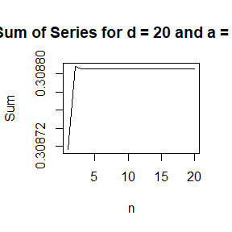

```r
#画出更直观的曲线逼近、
d <- 100
a <- c(1, 2)
n_values <- seq(1, 20, by = 1) # 创建一个从1到20的n值向量
sum_values <- sapply(n_values, n_sum, d = d, a = a) # 计算每个n值的级数和
plot(n_values, sum_values, type = "l", xlab = "n", ylab = "Sum", main = "Sum of Series for d = 20 and a = (1, 2)")
```

可见在n=5后基本逼近级数值，该无穷级数求和为0.3088054。

## Question

Write a function to solve an equation

## Answer

```r
# 计算积分的辅助函数
integrate_function <- function(k, a, c_k) {
  integrand <- function(u) {
    (1 + (u^2) / k)^(-(k+1)/2)
  }
  result <- integrate(integrand, lower = 0, upper = c_k)
  return(result$value)
}

# 计算方程左边的函数
left_side <- function(k, a) {
  c_k <- sqrt(a^2 * (k-1) / (k - a^2))
  integral_value <- integrate_function(k-1, a, c_k)
  (2 * gamma(k/2)) / (sqrt(pi * (k - 1)) * gamma((k - 1)/2)) * integral_value
}

# 计算方程右边的函数
right_side <- function(k, a) {
  c_k <- sqrt(a^2 * k / (k + 1 - a^2))
  integral_value <- integrate_function(k, a, c_k)
  (2 * gamma((k + 1)/2)) / (sqrt(pi * k) * gamma(k/2)) * integral_value
}

#求根
f <- function(a,k) left_side(k,a)-right_side(k,a)
res <- uniroot(f,c(0.5,4),k=25)

unlist(res)[1:3]
```

```
##          root        f.root          iter
##  1.687346e+00 -2.656033e-10  9.000000e+00
```

```r
unlist(res)[-(1:3)]
```

```
##      init.it   estim.prec
##           NA 6.103516e-05
```

可见当k=25时，方程根为1.687；

```r
res <- uniroot(f,c(0.5,1.8),k=4)
print(paste0("k=4时："))
```

```
## [1] "k=4时："
```

```r
unlist(res)[1:3]
```

```
##         root       f.root         iter
## 1.492106e+00 1.391513e-07 5.000000e+00
```

```r
res <- uniroot(f,c(0.5,1.8),k=15)
print(paste0("k=15时："))
```

```
## [1] "k=15时："
```

```r
unlist(res)[1:3]
```

```
##          root        f.root          iter
##  1.659096e+00 -3.049831e-10  5.000000e+00
```

```r
res <- uniroot(f,c(0.5,4),k=25)
print(paste0("k=25时："))
```

```
## [1] "k=25时："
```

```r
unlist(res)[1:3]
```

```
##          root        f.root          iter
##  1.687346e+00 -2.656033e-10  9.000000e+00
```

```r
res <- uniroot(f,c(0.5,5),k=100)
print(paste0("k=100时："))
```

```
## [1] "k=100时："
```

```r
unlist(res)[1:3]
```

```
##          root        f.root          iter
##  1.720590e+00 -2.539439e-10  8.000000e+00
```

the solutions is identical with the points A(k) in Exercise 11.4.

## Question

Use the E-M algorithm to estimate λ, compare your result with the observed data MLE (note: Yi follows a mixture distribution).

## Answer

```r
# 定义EM算法的函数
myem <- function(Yi, tau=1, max_iter = 100, tol = 1e-6) {
  n <- length(Yi)
  # 初始化参数
  lambda <- 1/mean(Yi)

  # EM算法迭代
  for (i in 1:max_iter) {
    # E步：对数似然均值
    Yi[5]<-1+1/lambda
    Yi[6]<-1+1/lambda
    Yi[8]<-1+1/lambda

    # M步：更新lambda的估计
    lambda_new <- 1 / mean(Yi)

    # 检查收敛性
    if (abs(lambda_new - lambda) < tol) {
      break
    }
    lambda <- lambda_new
  }

  return(list(lambda = lambda, iterations = i))
}

# 观察到的数据Yi
Yi <- c(0.54, 0.48, 0.33, 0.43, 1.00, 1.00, 0.91, 1.00, 0.21, 0.85)
tau <- 1

# 运行EM算法
em_result <- myem(Yi, tau)
print(em_result)
```

```
## $lambda
## [1] 1.037038
##
## $iterations
## [1] 12
```

```r
#MLE
#该数据对应的对数似然函数
Y1<-c(0.54, 0.48, 0.33, 0.43, 0.91, 0.21, 0.85)
fu<-function(x) 7*log(x)-sum(Y1)*x-3*x
optimize(fu,lower=0.5,upper=5,maximum=TRUE)
```

```
## $maximum
## [1] 1.037044
##
## $objective
## [1] -6.745426
```

可见EM算法的结果和MLE非常接近。

# hw8

## Question

Use the simplex algorithm to solve the following problem. Minimize 4x + 2y + 9z

## Answer

```r
rm(list=ls())
library(lpSolve)
f.obj <- c(4, 2, 9)#objective.in
f.con <- matrix (c(2, 1, 1, 1, -1, 3),
                 nrow=2, byrow=TRUE)#const.mat
f.dir <- c("<=", "<=")#const.dir
f.rhs <- c(2, 3)
#Vector of numeric values for the right-hand sides of the constraints.
print("x,y,z分别取：")
```

```
## [1] "x,y,z分别取："
```

```r
lp ("min", f.obj, f.con, f.dir, f.rhs)$solution
```

```
## [1] 0 0 0
```

```r
print("此时，目标函数达到最小值：")
```

```
## [1] "此时，目标函数达到最小值："
```

```r
lp ("min", f.obj, f.con, f.dir, f.rhs)
```

```
## Success: the objective function is 0
```

## Question

Use both for loops and lapply() to fit linear models to the mtcars using the formulas stored in this list

## Answer

```r
##loops
# mtcars数据集
data(mtcars)
formulas <- list(
  mpg ~ disp,
  mpg ~ I(1 / disp),
  mpg ~ disp + wt,
  mpg ~ I(1 / disp) + wt
)

# 使用for语句循环
for (i in 1:4) {
  model<- lm(formulas[[i]], data = mtcars)
  print(model)
}
```

```
##
## Call:
## lm(formula = formulas[[i]], data = mtcars)
##
## Coefficients:
## (Intercept)         disp
##    29.59985     -0.04122
##
##
## Call:
## lm(formula = formulas[[i]], data = mtcars)
##
## Coefficients:
## (Intercept)    I(1/disp)
##       10.75      1557.67
##
##
## Call:
## lm(formula = formulas[[i]], data = mtcars)
##
## Coefficients:
## (Intercept)         disp           wt
##    34.96055     -0.01772     -3.35083
##
##
## Call:
## lm(formula = formulas[[i]], data = mtcars)
##
## Coefficients:
## (Intercept)    I(1/disp)           wt
##      19.024     1142.560       -1.798
```

```r
# lapply向量化
fun<-function(formula) {lm(formula, data = mtcars)}
fits <- lapply(formulas, fun)
print(fits)
```

```
## [[1]]
##
## Call:
## lm(formula = formula, data = mtcars)
##
## Coefficients:
## (Intercept)         disp
##    29.59985     -0.04122
##
##
## [[2]]
##
## Call:
## lm(formula = formula, data = mtcars)
##
## Coefficients:
## (Intercept)    I(1/disp)
##       10.75      1557.67
##
##
## [[3]]
##
## Call:
## lm(formula = formula, data = mtcars)
##
## Coefficients:
## (Intercept)         disp           wt
##    34.96055     -0.01772     -3.35083
##
##
## [[4]]
##
## Call:
## lm(formula = formula, data = mtcars)
##
## Coefficients:
## (Intercept)    I(1/disp)           wt
##      19.024     1142.560       -1.798
```

两种方式得到相同的结果，但lapply向量化提高运算速度，且写法更简洁。

## Question

Fit the model mpg ~ disp to each of the bootstrap replicates of mtcars in the list below by using a for loop and lapply(). Can you do it without an anonymous function?

## Answer

```r
bootstraps <- lapply(1:10, function(i) {
rows <- sample(1:nrow(mtcars), rep = TRUE)
mtcars[rows, ]
})

# loops
for (i in 1:10) {
  # 拟合模型
  fit <- lm(formulas[[1]], data = bootstraps[[i]])
  # 打印模型摘要
  print(paste0("Fit result for boot ", i, ":"))
  print(fit)
}
```

```
## [1] "Fit result for boot 1:"
##
## Call:
## lm(formula = formulas[[1]], data = bootstraps[[i]])
##
## Coefficients:
## (Intercept)         disp
##    29.91398     -0.04125
##
## [1] "Fit result for boot 2:"
##
## Call:
## lm(formula = formulas[[1]], data = bootstraps[[i]])
##
## Coefficients:
## (Intercept)         disp
##    31.41483     -0.04699
##
## [1] "Fit result for boot 3:"
##
## Call:
## lm(formula = formulas[[1]], data = bootstraps[[i]])
##
## Coefficients:
## (Intercept)         disp
##    30.64939     -0.04859
##
## [1] "Fit result for boot 4:"
##
## Call:
## lm(formula = formulas[[1]], data = bootstraps[[i]])
##
## Coefficients:
## (Intercept)         disp
##    32.40911     -0.05457
##
## [1] "Fit result for boot 5:"
##
## Call:
## lm(formula = formulas[[1]], data = bootstraps[[i]])
```

[output cut: 34 more lines]

```
## Call:
## lm(formula = formulas[[1]], data = bootstraps[[i]])
##
## Coefficients:
## (Intercept)         disp
##    29.40919     -0.03749
##
## [1] "Fit result for boot 10:"
##
## Call:
## lm(formula = formulas[[1]], data = bootstraps[[i]])
##
## Coefficients:
## (Intercept)         disp
##     32.1103      -0.0493
```

```r
##lapply列表
#without an anonymous function
#...    :optional arguments to FUN
fits2 <- lapply(bootstraps, lm, formula = formulas[[1]])

print(fits2)
```

```
## [[1]]
##
## Call:
## FUN(formula = ..1, data = X[[i]])
##
## Coefficients:
## (Intercept)         disp
##    29.91398     -0.04125
##
##
## [[2]]
##
## Call:
## FUN(formula = ..1, data = X[[i]])
##
## Coefficients:
## (Intercept)         disp
##    31.41483     -0.04699
##
##
## [[3]]
##
## Call:
## FUN(formula = ..1, data = X[[i]])
##
## Coefficients:
## (Intercept)         disp
##    30.64939     -0.04859
##
##
## [[4]]
##
## Call:
## FUN(formula = ..1, data = X[[i]])
##
## Coefficients:
## (Intercept)         disp
##    32.40911     -0.05457
##
##
```

[output cut: 43 more lines]

```
## FUN(formula = ..1, data = X[[i]])
##
## Coefficients:
## (Intercept)         disp
##    29.40919     -0.03749
##
##
## [[10]]
##
## Call:
## FUN(formula = ..1, data = X[[i]])
##
## Coefficients:
## (Intercept)         disp
##     32.1103      -0.0493
```

## Question

For each model in the previous two exercises, extract R2 using the function below.

## Answer

```r
rsq <- function(mod) summary(mod)$r.squared
## ex3
print("R^2 of ex3 model : ")
```

```
## [1] "R^2 of ex3 model : "
```

```r
lapply(fits,rsq)
```

```
## [[1]]
## [1] 0.7183433
##
## [[2]]
## [1] 0.8596865
##
## [[3]]
## [1] 0.7809306
##
## [[4]]
## [1] 0.8838038
```

```r
## ex4
print("R^2 of ex4 model : ")
```

```
## [1] "R^2 of ex4 model : "
```

```r
lapply(fits2,rsq)
```

```
## [[1]]
## [1] 0.7285796
##
## [[2]]
## [1] 0.7442686
##
## [[3]]
## [1] 0.8245614
##
## [[4]]
## [1] 0.8024319
##
## [[5]]
## [1] 0.7382983
##
## [[6]]
## [1] 0.6167292
##
## [[7]]
## [1] 0.7310478
##
## [[8]]
## [1] 0.7685775
##
## [[9]]
## [1] 0.6517089
##
## [[10]]
## [1] 0.7910998
```

## Question

The following code simulates the performance of a t-test for non-normal data. Use sapply() and an anonymous function to extract the p-value from every trial.

## Answer

```r
set.seed(123)
trials <- replicate(
100,
t.test(rpois(10, 10), rpois(7, 10)),
simplify = FALSE
)

#Use sapply() and an anonymous function
sapply(trials, function(x) x$p.value)
```

```
##   [1] 9.813226e-01 1.619096e-05 6.242135e-01 6.693526e-01 5.677105e-01
##   [6] 6.610740e-01 5.951636e-01 5.005347e-01 4.763110e-01 3.429965e-01
##  [11] 8.155394e-01 7.197238e-01 1.244336e-01 2.229164e-01 1.113099e-02
##  [16] 4.625765e-01 6.515865e-01 1.658793e-01 9.342672e-01 8.011934e-01
##  [21] 4.627657e-01 5.927934e-01 2.929669e-01 5.737967e-01 3.451537e-02
##  [26] 2.739138e-01 2.656151e-01 8.196695e-01 6.647355e-01 8.056529e-01
##  [31] 5.060850e-01 7.106543e-01 2.321066e-01 1.106223e-01 5.459279e-01
##  [36] 1.865470e-02 2.433776e-01 2.688851e-01 9.819256e-01 4.940184e-01
##  [41] 3.268275e-01 8.000439e-01 9.822499e-01 1.936454e-01 7.390101e-01
##  [46] 3.888930e-02 4.350424e-01 7.434339e-02 5.787441e-01 4.864951e-01
##  [51] 1.476288e-01 5.524909e-01 7.129280e-01 8.683479e-03 9.053256e-02
##  [56] 4.415463e-01 4.955063e-01 1.745328e-01 6.615399e-01 4.479199e-01
##  [61] 2.885849e-01 3.028567e-02 1.018907e-01 1.811861e-02 6.376441e-01
##  [66] 1.408742e-02 9.008128e-02 4.515933e-01 8.703291e-01 7.250768e-01
##  [71] 8.183571e-01 8.465036e-01 8.786838e-01 1.651543e-01 3.951569e-01
##  [76] 1.754280e-01 3.649865e-01 7.224226e-02 6.565152e-01 9.946559e-01
##  [81] 3.715952e-01 8.424336e-02 4.549887e-01 8.530113e-01 1.970777e-01
##  [86] 2.298117e-01 1.148832e-01 7.769502e-01 4.934348e-01 3.526049e-01
##  [91] 2.036013e-01 8.838914e-01 6.474880e-02 4.089082e-01 5.780132e-01
##  [96] 8.011408e-01 5.956061e-01 9.266689e-01 9.923205e-02 1.763972e-01
```

```r
#Use sapply() and without anonymous function
#by using [[ directly.
sapply(trials, "[[", "p.value")
```

```
##   [1] 9.813226e-01 1.619096e-05 6.242135e-01 6.693526e-01 5.677105e-01
##   [6] 6.610740e-01 5.951636e-01 5.005347e-01 4.763110e-01 3.429965e-01
##  [11] 8.155394e-01 7.197238e-01 1.244336e-01 2.229164e-01 1.113099e-02
##  [16] 4.625765e-01 6.515865e-01 1.658793e-01 9.342672e-01 8.011934e-01
##  [21] 4.627657e-01 5.927934e-01 2.929669e-01 5.737967e-01 3.451537e-02
##  [26] 2.739138e-01 2.656151e-01 8.196695e-01 6.647355e-01 8.056529e-01
##  [31] 5.060850e-01 7.106543e-01 2.321066e-01 1.106223e-01 5.459279e-01
##  [36] 1.865470e-02 2.433776e-01 2.688851e-01 9.819256e-01 4.940184e-01
##  [41] 3.268275e-01 8.000439e-01 9.822499e-01 1.936454e-01 7.390101e-01
##  [46] 3.888930e-02 4.350424e-01 7.434339e-02 5.787441e-01 4.864951e-01
##  [51] 1.476288e-01 5.524909e-01 7.129280e-01 8.683479e-03 9.053256e-02
##  [56] 4.415463e-01 4.955063e-01 1.745328e-01 6.615399e-01 4.479199e-01
##  [61] 2.885849e-01 3.028567e-02 1.018907e-01 1.811861e-02 6.376441e-01
##  [66] 1.408742e-02 9.008128e-02 4.515933e-01 8.703291e-01 7.250768e-01
##  [71] 8.183571e-01 8.465036e-01 8.786838e-01 1.651543e-01 3.951569e-01
##  [76] 1.754280e-01 3.649865e-01 7.224226e-02 6.565152e-01 9.946559e-01
##  [81] 3.715952e-01 8.424336e-02 4.549887e-01 8.530113e-01 1.970777e-01
##  [86] 2.298117e-01 1.148832e-01 7.769502e-01 4.934348e-01 3.526049e-01
##  [91] 2.036013e-01 8.838914e-01 6.474880e-02 4.089082e-01 5.780132e-01
##  [96] 8.011408e-01 5.956061e-01 9.266689e-01 9.923205e-02 1.763972e-01
```

## Question

Implement a combination of Map() and vapply() to create an lapply() variant that iterates in parallel over all of its inputs and stores its outputs in a vector (or a matrix). What arguments should the function take?

## Answer

```r
## 编写lapply变形函数--Lappy
#形参：
#FUN--the function to be applied to each element of X
#...--多个X
#FUN.VALUE  --a (generalized) vector; a template for the return value from FUN
Lapply<-function(FUN, ..., FUN.VALUE=numeric(1), sim = TRUE) {
  # 使用Map实现对...中的每个元的并行
  re <- Map(FUN, ...)
  # vapply
  res <- vapply(re, function(x) {
    # 使用FUN.VALUE[[1]]为模板
    if (length(FUN.VALUE) == 1) {
      return(x[[1]])
    } else {
      stop("FUN.VALUE must be a vector of length 1")
    }
  }, FUN.VALUE)

  # 如果simplify为TRUE且结果为一维，则简化输出为向量
  if (sim && is.list(res) && length(res) == 1) {
    return(res[[1]])
  }

  # 返回结果
  return(res)
}
```

```r
##举例使用上述函数
my_fun <- function(x, y) {
  x ^ y
}

# 并行应用myFUN到两个向量上
result <- Lapply(my_fun, 1:3, 4:6, FUN.VALUE = numeric(1),sim = TRUE)

# 打印结果
print(result)
```

```
## [1]   1  32 729
```

```r
is.vector(result)|is.matrix(result)#检验结果是否向量/矩阵形式
```

```
## [1] TRUE
```

## Question

Make a faster version of chisq.test() that only computes the chi-square test statistic when the input is two numeric vectors with no missing values.

## Answer

```r
#编写更快的检验函数
my_chisq.test <- function(x, y) {
  # 默认确保输入是数值型向量且无缺失值
  # 根据卡方检验公式，尽量向量化
  tab <- table(x, y)
  obs <- as.vector(tab)
  ##利用outer外积
  exp <- outer(rowSums(tab), colSums(tab)) / sum(tab)
  # 卡方检验统计量
  result <- sum((obs - exp)^2 / exp)
  return(result)
}
```

```r
##举例使用上述函数
set.seed(123)
x <- sample(1:7, 50, replace = TRUE)
y <- sample(1:7, 50, replace = TRUE)

# 计算卡方检验统计量
my_chisq.test(x, y)
```

```
## [1] 60.23639
```

## Question

make a faster version of table() for the case of an input of two integer vectors with no missing values

use it to speed up your chi-square test

## Answer

```r
## mytab：
mytab <- function(x, y) {

  # 去重
  unique_x <- sort(unique(x))
  unique_y <- sort(unique(y))
  # 计算频数矩阵
  xcol<-function(i){
    sapply(unique_y,function(j) sum(y[x==i]==j))
  } #向量化，得到第i行
  freq<-t(as.matrix(sapply(unique_x,xcol)))
  rownames(freq)<-unique_x
  colnames(freq)<-unique_y
  # 返回频数向量
  return(freq)
}
```

```r
##举例使用上述函数
x <- sample(2:7, 50, replace = TRUE)
y <- sample(3:8, 50, replace = TRUE)
mytab(x,y) #行名为x，列为y
```

```
##   3 4 5 6 7 8
## 2 0 3 0 0 0 0
## 3 0 1 1 2 1 3
## 4 2 1 1 2 2 1
## 5 0 1 1 1 2 2
## 6 1 0 0 3 2 1
## 7 6 1 3 2 2 2
```

```r
table(x,y)#验证和table结果相同
```

```
##    y
## x   3 4 5 6 7 8
##   2 0 3 0 0 0 0
##   3 0 1 1 2 1 3
##   4 2 1 1 2 2 1
##   5 0 1 1 1 2 2
##   6 1 0 0 3 2 1
##   7 6 1 3 2 2 2
```

```r
#use it to speed up your chi-square test?

my_chisq.test2 <- function(x, y) {
  # 默认确保输入是数值型向量且无缺失值
  # 根据卡方检验公式，尽量向量化
  tab <- mytab(x, y)
  obs <- as.vector(tab)
  ##利用outer外积
  exp <- outer(rowSums(tab), colSums(tab)) / sum(tab)
  # 卡方检验统计量
  result <- sum((obs - exp)^2 / exp)
  return(result)
}
```

```r
##举例使用上述函数
set.seed(123)
x <- sample(1:7, 50, replace = TRUE)
y <- sample(1:7, 50, replace = TRUE)

# 计算卡方检验统计量
my_chisq.test2(x, y)#结果是相同的，速度增大了
```

```
## [1] 60.23639
```

# hw9

## Question

Write an Rcpp function for Exercise 9.8

## Answer

```r
rm(list=ls())
```

```r
#the R function
gibb<-function(m,cut,n=10,a=1,b=1){
  x<-numeric(m)
  y<-numeric(m)
  x[1]<-rbinom(1,n,1/2)
  y[1]<-rbeta(1,x[1]+a,n-x[1]+b)
  for (i in 2:m) {
    x[i]<-rbinom(1,n,y[i-1])
    y[i]<-rbeta(1,x[i-1]+a,n-x[i-1]+b)
  }
  x<-x[(cut+1):m]
  y<-y[(cut+1):m]
  f<-matrix(c(x,y),nrow = (m-cut),ncol = 2)
}
```

```r
#相应的C++版本,具体可见压缩包中的gibbs.cpp
library(Rcpp)
dir_cpp <- 'D:/Download/RStudio/R-4.2.2/library/Rcpp/myfun/'
#路径
sourceCpp(paste0(dir_cpp,"gibbs.cpp"))
```

```r
# 生成1000个数据的MC
set.seed(123)
g_c<-gibbs(2000,1000) #Rcpp
g_r<-gibb(2000,1000)  #R function
```

## Question

Compare the corresponding generated random numbers with those by the R function you wrote using the function “qqplot”.

## Answer

```r
#Compare the corresponding generated random numbers
#with those by the R function
#对x分量标准化以便画qq图
g_c[,1]<-(g_c[,1]-min(g_c[,1]))/(max(g_c[,1])-min(g_c[,1]))
g_r[,1]<-(g_r[,1]-min(g_r[,1]))/(max(g_r[,1])-min(g_r[,1]))
qqplot(g_c[,1],g_r[,1],main="x--qqplot")
qqplot(g_c[,2],g_r[,2],main="y--qqplot")
```

[output not shown]

## Question

Campare the computation time of the two functions with the function “microbenchmark”.

## Answer

```r
#m=5000
library(microbenchmark)
ts <- microbenchmark(gC=gibbs(5000,1000),gR=gibb(5000,1000))
summary(ts)[,c(1,3,5,6)]
```

[output not shown]